# Modeling weed community diversity based on species population density dynamics and herbicide use intensity - ScienceDirect

[figure not shown]

## Figures (6)

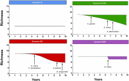

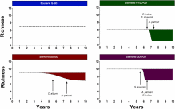

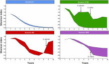

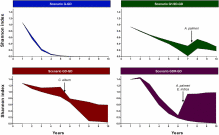

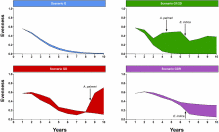

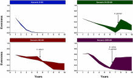

[figure not shown]

## [European Journal of Agronomy](https://www.sciencedirect.com/journal/european-journal-of-agronomy)

[Volume 138](https://www.sciencedirect.com/journal/european-journal-of-agronomy/vol/138/suppl/C), August 2022, 126533

# Modeling weed community diversity based on species population density dynamics and herbicide use intensity

[Fernando H.Oreja<sup>a</sup><sup>b</sup>](https://www.sciencedirect.com/science/article/abs/pii/S1161030122000818#!)[Matthew D.Inman<sup>a</sup>](https://www.sciencedirect.com/science/article/abs/pii/S1161030122000818#!)[David L.Jordan<sup>a</sup>](https://www.sciencedirect.com/science/article/abs/pii/S1161030122000818#!)[DeepayanBardhan<sup>a</sup>](https://www.sciencedirect.com/science/article/abs/pii/S1161030122000818#!)[Ramon G.Leon<sup>a</sup><sup>c</sup><sup>d</sup>](https://www.sciencedirect.com/science/article/abs/pii/S1161030122000818#!)

## Highlights

**•**

More herbicides in the program does not imply higher rates of species eradication.

**•**

Some herbicide programs can minor effects on richness but have strong effects on diversity and evenness.

**•**

Eradication of species with high population growth rates can an increase diversity and evenness.

**•**

The effects of a herbicide program on weed community composition remain for several years after changing to another herbicide program.

## Abstract

Herbicide programs change weed population density as well as weed community composition. The repeated use of a given program can result in a weed community that progressively becomes more difficult to manage or could lose its ability to provide ecosystem services. Simulation of those changes using stochastic models considering population dynamics of multiple species makes it possible to identify a priori potential community changes that might result from the use of a given herbicide program. The objectives of this work were to model the population dynamics of weed species under different herbicide programs and how those dynamics change weed community diversity over time. [Weed population dynamics](https://www.sciencedirect.com/topics/agricultural-and-biological-sciences/weed-population-dynamics) were stochastically modeled along ten years using population growth rate (lambda) for each species under different herbicide programs. Lambda values were obtained from an eight-year long, field experiment, and these were used to parameterize the stochastic ranges for the model for each weed species. Population trajectories were modeled for each individual species over ten years and the results were used to estimate richness, diversity, and evenness for each herbicide use scenario. The repeated use of glyphosate alone had a minimal effect on richness, but it caused a strong reduction in weed diversity and evenness. Programs with more mechanisms of action and the use of both preemergence and postemergence herbicides were slightly more likely to suffer the loss of weed species than programs with single or just a few herbicides. Conversely, the former had a higher probability of maintaining weed diversity and evenness than the latter. According to simulations, losses in weed community diversity are reversible, especially when highly competitive species were eradicated allowing other species with lower lambda to increase their populations. However, the eradication of species with low reproductive rates reduced diversity and evenness. The effects of herbicide programs on the weed community lasted for several years even after those programs were modified indicating that seed banks play a major buffering role in the rate of change of weed community composition. Thus, frequent changes in management interrupting the repeated use of specific weed control programs, even under high herbicide intensity use (i.e., number of applications and mechanisms of action), can help maintain weed diversity in agroecosystems.

## Keywords

*Amaranthus palmeri*

*Eleusine indica*

Dicamba

Diversity

Evenness

Glyphosate

Richness

© 2022 Elsevier B.V. All rights reserved.

[figure not shown]

[figure not shown]